[figure not shown]

# Завдання до лабораторної роботи №2

### Хiд виконання роботи:

1. Представити початковi данi графiчно.
2. Розбити данi на навчальний i перевiрочний набори.
3. Побудувати моделi класифiкацiї або регресiї згiдно з варiантом.
4. Представити моделi графiчно.
5. Виконати прогнози на основi моделей.
6. Для кожної з моделей оцiнити, чи має мiсце перенавчання.
7. Розрахувати додатковi результати моделей, наприклад, апостерiорнi iмовiрностi, опорнi вектори або iншi (згiдно з варiантом).
8. Для задач класифiкацiї розрахувати критерiї якостi для кожної моделi:  
   • матрицю неточностей (confusion matrix),  
   • точнiсть (precision),  
   • повноту (recall),  
   • мiру F1 (F1 score),  
   • побудувати криву точностi-повноти (precision-recall (PR) curve), ROC-криву, показник AUC.
9. Виконати перехресну перевiрку i решiтчатий пошук для пiдбору гiперпараметрiв моделей.
10. Зробити висновки про якiсть роботи моделей на дослiджених даних. Для кожної навчальної вибiрки вибрати найкращу модель.
11. Навчити моделi на пiдмножинах навчальних даних. Оцiнити, наскiльки розмiр навчальної множини впливає на якiсть моделi.

### Варіант 5, КА-75

Побудувати моделi класифiкацiї на основi методу дерев рiшень, викори стовуючи `sklearn.tree.DecisionTreeClassifier` з рiзними значеннями гiперпараметрiв:  
• `max_depth` – максимальна глибина дерева,  
• `min_samples_split` – мiнiмальна кiлькiсть прикладiв, якi мають бути у вузлi, перш нiж його можна буде розщепити,  
• `min_samples_leaf` – мiнiмальна кiлькiсть прикладiв у листовому вузлi,  
• `max_leaf_nodes` – максимальна кiлькiсть листових вузлiв,  
• `max_features` – максимальна кiлькiсть ознак, якi оцiнюються при розщепленнi кожного вузла.

Побудувати границi рiшень графiчно для кожної з моделей.  
Настроїти гiперпараметри дерева за допомогою перехресної перевiрки.

**Початковi данi:**  
(а) `sklearn.datasets.load_digits`  
(б) `sklearn.datasets.make_moons`

## Хід роботи

### 1. Представити початковi данi графiчно.

**load_digits** - load and return the digits dataset (classification).

Each datapoint is a 8x8 image of a digit.

> Classes - 10  
> Samples per class - ~180  
> Samples total - 1797  
> Dimensionality - 64  
> Features integers - 0-16

`X_digits` - ознаки (features) цифр  
`y_digits` - цільова змінна - класи цифр

```python
import matplotlib.pyplot as plt
```

```python
from sklearn.datasets import load_digits

digits = load_digits()
X_digits, y_digits = digits.data, digits.target
```

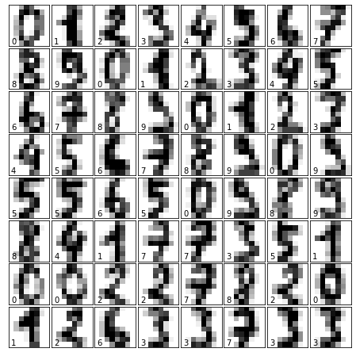

```python
fig = plt.figure(figsize=(6, 6))  # figure size in inches
fig.subplots_adjust(left=0, right=1, bottom=0, top=1, hspace=0.05, wspace=0.05)

for i in range(64):
    ax = fig.add_subplot(8, 8, i + 1, xticks=[], yticks=[])
    ax.imshow(digits.images[i], cmap=plt.cm.binary, interpolation='nearest')
    ax.text(0, 7, str(y_digits[i]))
```

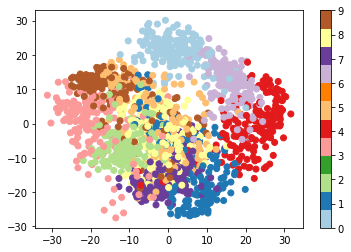

```python
plt.figure()

from sklearn.decomposition import PCA
pca = PCA(n_components=2)
proj = pca.fit_transform(X_digits)
plt.scatter(proj[:, 0], proj[:, 1], c=y_digits, cmap="Paired")
plt.colorbar()
```

**make_moons** - make two interleaving half circles. A simple toy dataset to visualize clustering and classification algorithms.

`X_moons` - згенерована виборка  
`y_moons` - цільовий клас (0 або 1)

```python
from sklearn.datasets import make_moons
from pandas import DataFrame

X_moons, y_moons = make_moons(n_samples=1000, noise=0.2)
```

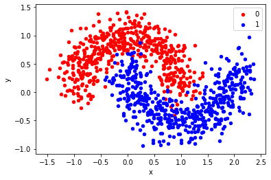

```python
df = DataFrame(dict(x=X_moons[:,0], y=X_moons[:,1], label=y_moons))
colors = {0:'red', 1:'blue'}
fig, ax = plt.subplots()
grouped = df.groupby('label')
for key, group in grouped:
    group.plot(ax=ax, kind='scatter', x='x', y='y', label=key, color=colors[key])
plt.show()
```

### 2. Розбити данi на навчальний i перевiрочний набори.

Розбиваємо дані у наступному співвідношенні: 80% - дані для тренування, 20% - дані для перевірки.

`X_digits_train, y_digits_train` - дані для тренування моделі на датасеті load_digits  
`X_digits_test, y_digits_test` - дані для оцінки точності моделі

```python
from sklearn.model_selection import train_test_split

X_digits_train, X_digits_test, y_digits_train, y_digits_test = \
    train_test_split(X_digits, y_digits, test_size=0.2, random_state=0)

print(X_digits_train.shape, y_digits_train.shape)
print(X_digits_test.shape, y_digits_test.shape)
```

```
(1437, 64) (1437,)
(360, 64) (360,)
```

`X_moons_train, y_moons_train` - дані для тренування моделі на датасеті make_moons  
`X_moons_test, y_moons_test` - дані для оцінки точності моделі

```python
X_moons_train, X_moons_test, y_moons_train, y_moons_test = \
    train_test_split(X_moons, y_moons, test_size=0.2, random_state=0)

print(X_moons_train.shape, y_moons_train.shape)
print(X_moons_test.shape, y_moons_test.shape)
```

```
(800, 2) (800,)
(200, 2) (200,)
```

### 3. Побудувати моделi класифiкацiї.

Побудувати моделi класифiкацiї на основi методу дерев рiшень, викори стовуючи `sklearn.tree.DecisionTreeClassifier` з рiзними значеннями гiперпараметрiв:  
• `max_depth` – максимальна глибина дерева,  
• `min_samples_split` – мiнiмальна кiлькiсть прикладiв, якi мають бути у вузлi, перш нiж його можна буде розщепити,  
• `min_samples_leaf` – мiнiмальна кiлькiсть прикладiв у листовому вузлi,  
• `max_leaf_nodes` – максимальна кiлькiсть листових вузлiв,  
• `max_features` – максимальна кiлькiсть ознак, якi оцiнюються при розщепленнi кожного вузла.

#### Побудова моделі за самостійно підібраними значеннями гіпермараметрів

*load_digits*

```python
from sklearn.tree import DecisionTreeClassifier

decisionTree_digits = DecisionTreeClassifier(max_depth=32, min_samples_leaf=8,
                                             min_samples_split=16, max_features=16,
                                             max_leaf_nodes = 64)
decisionTree_digits.fit(X_digits_train, y_digits_train)
```

```
DecisionTreeClassifier(ccp_alpha=0.0, class_weight=None, criterion='gini',
                       max_depth=32, max_features=16, max_leaf_nodes=64,
                       min_impurity_decrease=0.0, min_impurity_split=None,
                       min_samples_leaf=8, min_samples_split=16,
                       min_weight_fraction_leaf=0.0, presort='deprecated',
                       random_state=None, splitter='best')
```

*make_moons*

```python
decisionTree_moons = DecisionTreeClassifier(max_depth=8, max_leaf_nodes = 24)
decisionTree_moons.fit(X_moons_train, y_moons_train)
```

```
DecisionTreeClassifier(ccp_alpha=0.0, class_weight=None, criterion='gini',
                       max_depth=8, max_features=None, max_leaf_nodes=24,
                       min_impurity_decrease=0.0, min_impurity_split=None,
                       min_samples_leaf=1, min_samples_split=2,
                       min_weight_fraction_leaf=0.0, presort='deprecated',
                       random_state=None, splitter='best')
```

### 4. Представити моделi графiчно.

Графіки будуємо за допомогою `export_graphviz` і зберігаємо у файлах 'digits_tree.png' та 'moons_tree.png'.

```python
from sklearn.tree import export_graphviz
export_graphviz(decisionTree_digits, out_file='img/digits_tree.dot', filled=True)
!dot -Tpng 'img/digits_tree.dot' -o 'img/digits_tree.png'
```

[figure not shown]

```python
export_graphviz(decisionTree_moons, out_file='img/moons_tree.dot', filled=True)
!dot -Tpng 'img/moons_tree.dot' -o 'img/moons_tree.png'
```

[figure not shown]

### 5. Виконати прогнози на основi моделей.

```python
predictions_digits = decisionTree_digits.predict(X_digits_test)
```

```python
score_digits = decisionTree_digits.score(X_digits_test, y_digits_test)
print(score_digits)
```

```
0.7916666666666666
```

```python
predictions_moons = decisionTree_moons.predict(X_moons_test)
score_moons = decisionTree_moons.score(X_moons_test, y_moons_test)
print(score_moons)
```

```
0.95
```

### 6. Для кожної з моделей оцiнити, чи має мiсце перенавчання.

```python
from sklearn.metrics import f1_score

predictions_digits_train = decisionTree_digits.predict(X_digits_train)

print('f1-score:')
print(f'Train: {f1_score(y_digits_train, predictions_digits_train, average="macro")}')
print(f'Test: {f1_score(y_digits_test, predictions_digits, average="macro")}')
```

```
f1-score:
Train: 0.8627434418858044
Test: 0.7908304729621577
```

На тренувальній вибірці модель показує кращу якість, ніж на тестовій. Тому очевидно, що **перенавчання має місце**.

```python
predictions_moons_train = decisionTree_moons.predict(X_moons_train)

print('f1-score:')
print(f'Train: {f1_score(y_moons_train, predictions_moons_train, average="macro")}')
print(f'Test: {f1_score(y_moons_test, predictions_moons, average="macro")}')
```

```
f1-score:
Train: 0.9862451643155797
Test: 0.9499198717948718
```

Вважаючи, що на навчальній вибірці якість майже бездоганна, це означає, що **перенавчання має місце**, оскільки на тестовій вибірці результат також високий, але він все одно менше, ніж на тренувальній.

### 7. Розрахувати додатковi результати моделей, наприклад, апостерiорнi iмовiрностi, опорнi вектори або iншi (згiдно з варiантом)

**Побудувати границi рiшень графiчно для кожної з моделей.**  
Для датасету з цифр будування границь рішень для попарних характеристик не є інформативним (оскільки характеристики не залежать між собою), тому побудуємо границі рішень для датасету `make_moons`.

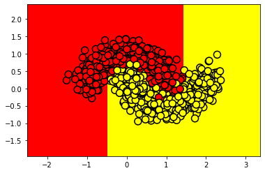

```python
import numpy as np

def get_grid(data):
    x_min, x_max = data[:, 0].min() - 1, data[:, 0].max() + 1
    y_min, y_max = data[:, 1].min() - 1, data[:, 1].max() + 1
    return np.meshgrid(np.arange(x_min, x_max, 0.01), np.arange(y_min, y_max, 0.01))

xx, yy = get_grid(X_moons_train)
predicted = decisionTree_moons.predict(np.c_[xx.ravel(), yy.ravel()]).reshape(xx.shape)
plt.pcolormesh(xx, yy, predicted, cmap='autumn')
plt.scatter(X_moons_train[:, 0], X_moons_train[:, 1], c=y_moons_train, s=100,
cmap='autumn', edgecolors='black', linewidth=1.5)
```

### 8. Для задач класифiкацiї розрахувати критерiї якостi для кожної моделi:

#### 1) Матрицю неточностей (confusion matrix)

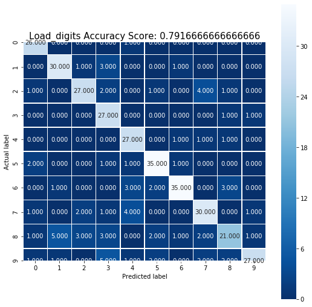

```python
import seaborn as sns
from sklearn import metrics

cm_digits = metrics.confusion_matrix(y_digits_test, predictions_digits)
plt.figure(figsize=(9,9))
sns.heatmap(cm_digits, annot=True, fmt=".3f", linewidths=.5, square = True, cmap = 'Blues_r')
plt.ylabel('Actual label')
plt.xlabel('Predicted label')
all_sample_title = f'Load_digits Accuracy Score: {score_digits}'
plt.title(all_sample_title, size = 15)
```

[figure not shown]

```python
cm_moons = metrics.confusion_matrix(y_moons_test, predictions_moons)
plt.figure(figsize=(5,5))
sns.heatmap(cm_moons, annot=True, fmt=".3f", linewidths=.5, square = True)
plt.ylabel('Actual label')
plt.xlabel('Predicted label')
all_sample_title = 'Make_moons Accuracy Score: {score_moons}'
plt.title(all_sample_title, size = 15)
```

#### 2) Точнiсть (precision)

```python
from sklearn.metrics import precision_score
ps_digits = precision_score(y_digits_test, predictions_digits, average='micro')
print('Load_digits:', ps_digits)
ps_moons = precision_score(y_moons_test, predictions_moons, average='micro')
print('Make_moons:', ps_moons)
```

```
Load_digits: 0.7916666666666666
Make_moons: 0.95
```

#### 3) Повноту (recall)

```python
from sklearn.metrics import recall_score
rs_digits = recall_score(y_digits_test, predictions_digits, average='micro')
print('Load_digits:', rs_digits)
rs_moons = recall_score(y_moons_test, predictions_moons, average='micro')
print('Make_moons:', rs_moons)
```

```
Load_digits: 0.7916666666666666
Make_moons: 0.95
```

#### 4) Мiру F1 (F1 score)

```python
from sklearn.metrics import f1_score
fs_digits = f1_score(y_digits_test, predictions_digits, average='micro')
print('Load_digits:', fs_digits)
fs_moons = f1_score(y_moons_test, predictions_moons, average='micro')
print('Make_moons:', fs_moons)
```

```
Load_digits: 0.7916666666666666
Make_moons: 0.9500000000000001
```

#### 5) Побудувати криву точностi-повноти (precision-recall (PR) curve), ROCкриву, показник AUC

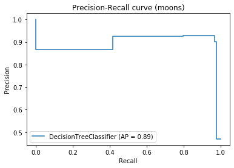

```python
from sklearn.metrics import plot_precision_recall_curve

pr_curve_moons = plot_precision_recall_curve(decisionTree_moons, X_moons_test, y_moons_test)
pr_curve_moons.ax_.set_title('Precision-Recall curve (moons)')
```

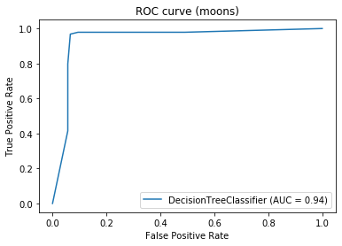

```python
from sklearn.metrics import plot_roc_curve

roc_curve_moons = plot_roc_curve(decisionTree_moons, X_moons_test, y_moons_test)
roc_curve_moons.ax_.set_title('ROC curve (moons)')
# plt.show()
```

Для того, щоб порахувати оцінку AUC потрібно змінити розмір масиву цільвої змінної. Для цього використаємо бібліотеку OneHotEncoder.

```python
from sklearn.metrics import roc_auc_score
from sklearn.preprocessing import OneHotEncoder

onehot_encoder = OneHotEncoder(sparse=False)
y_digits_encoded = y_digits_test.reshape(-1, 1)
onehot_encoded_test = onehot_encoder.fit_transform(y_digits_encoded)
prediction_digits_encoded = predictions_digits.reshape(-1, 1)
onehot_encoded_predict = onehot_encoder.fit_transform(prediction_digits_encoded)

auc_digits = roc_auc_score(onehot_encoded_test, onehot_encoded_predict, multi_class='ovr')
print('Load_digits:', auc_digits)
```

```
Load_digits: 0.8903615687167422
```

```python
auc_moons = roc_auc_score(y_moons_test, predictions_moons)
print('Make_moons:', auc_moons)
```

```
Make_moons: 0.9510236852669611
```

### 9. Виконати перехресну перевiрку i решiтчатий пошук для пiдбору гiперпараметрiв моделей.

Виконаємо пошук гіпермараметрів для датасету *load_digits*. Побудуємо модель та виконаємо прогнози.

```python
from sklearn.model_selection import GridSearchCV

params = {
'max_depth': list(range(4, 12)) + ['None'],
'min_samples_split': list(range(2, 6)) + ['None'],
'min_samples_leaf': list(range(1, 4)),
'max_leaf_nodes': list(range(20, 101, 4)),
'max_features': list(range(45, 66, 4)) + ['None']
}

grid_search_cv_digits = GridSearchCV(DecisionTreeClassifier(random_state=42), params, verbose=1, n_jobs=-1, cv=5)
grid_search_cv_digits.fit(X_digits_train, y_digits_train)
```

```
Fitting 5 folds for each of 19845 candidates, totalling 99225 fits
```

```
[Parallel(n_jobs=-1)]: Using backend LokyBackend with 4 concurrent workers.
[Parallel(n_jobs=-1)]: Done  68 tasks      | elapsed:    2.1s
[Parallel(n_jobs=-1)]: Done 2380 tasks      | elapsed:   11.8s
[Parallel(n_jobs=-1)]: Done 6380 tasks      | elapsed:   29.6s
[Parallel(n_jobs=-1)]: Done 14076 tasks      | elapsed:   56.1s
[Parallel(n_jobs=-1)]: Done 20220 tasks      | elapsed:  1.4min
[Parallel(n_jobs=-1)]: Done 28220 tasks      | elapsed:  2.0min
[Parallel(n_jobs=-1)]: Done 38196 tasks      | elapsed:  2.8min
[Parallel(n_jobs=-1)]: Done 48540 tasks      | elapsed:  3.7min
[Parallel(n_jobs=-1)]: Done 64860 tasks      | elapsed:  5.2min
[Parallel(n_jobs=-1)]: Done 82636 tasks      | elapsed:  6.8min
[Parallel(n_jobs=-1)]: Done 99225 out of 99225 | elapsed:  7.5min finished
```

```
GridSearchCV(cv=5, error_score=nan,
             estimator=DecisionTreeClassifier(ccp_alpha=0.0, class_weight=None,
                                              criterion='gini', max_depth=None,
                                              max_features=None,
                                              max_leaf_nodes=None,
                                              min_impurity_decrease=0.0,
                                              min_impurity_split=None,
                                              min_samples_leaf=1,
                                              min_samples_split=2,
                                              min_weight_fraction_leaf=0.0,
                                              presort='deprecated',
                                              random_state=42,
                                              splitter='best'),
             iid='deprecated', n_jobs=-1,
             param_grid={'max_depth': [4, 5, 6, 7, 8, 9, 10, 11, 'None'],
                         'max_features': [45, 49, 53, 57, 61, 65, 'None'],
                         'max_leaf_nodes': [20, 24, 28, 32, 36, 40, 44, 48, 52,
                                            56, 60, 64, 68, 72, 76, 80, 84, 88,
                                            92, 96, 100],
                         'min_samples_leaf': [1, 2, 3],
                         'min_samples_split': [2, 3, 4, 5, 'None']},
             pre_dispatch='2*n_jobs', refit=True, return_train_score=False,
             scoring=None, verbose=1)
```

```python
grid_search_cv_digits.best_estimator_
```

```
DecisionTreeClassifier(ccp_alpha=0.0, class_weight=None, criterion='gini',
                       max_depth=11, max_features=57, max_leaf_nodes=100,
                       min_impurity_decrease=0.0, min_impurity_split=None,
                       min_samples_leaf=1, min_samples_split=2,
                       min_weight_fraction_leaf=0.0, presort='deprecated',
                       random_state=42, splitter='best')
```

```python
grid_search_cv_digits.best_params_
```

```
{'max_depth': 11,
 'max_features': 57,
 'max_leaf_nodes': 100,
 'min_samples_leaf': 1,
 'min_samples_split': 2}
```

```python
export_graphviz( grid_search_cv_digits.best_estimator_, out_file='img/digits_best_tree.dot', filled=True)
!dot -Tpng 'img/digits_best_tree.dot' -o 'img/digits_best_tree.png'
```

[figure not shown]

```python
predictions_digits_best = grid_search_cv_digits.best_estimator_.predict(X_digits_test)
```

Порахуємо точність моделі:

```python
from sklearn.metrics import accuracy_score
score_digits_best = accuracy_score(y_digits_test, predictions_digits_best)
print('Load_digits:', score_digits_best)
```

```
Load_digits: 0.8638888888888889
```

Точність збільшилася, решітчатий пошук відпрацював добре. Цей результат найкращий, який змогла досягти модель. Кількість спроб побудувати модель залежить від параметрів машини. Оптимальне навантаження на мій комп'ютер дало таку точність моделі.

Виконаємо пошук гіпермараметрів для датасету *make_moons*. Побудуємо модель та виконаємо прогнози.

```python
params2 = {
'max_depth': list(range(4, 28)) + ['None'],
'min_samples_split': list(range(2, 6)) + ['None'],
'max_leaf_nodes': list(range(20, 100, 4))
}

grid_search_cv_moons = GridSearchCV(DecisionTreeClassifier(random_state=42), params2, verbose=1, n_jobs=-1, cv=5)
grid_search_cv_moons.fit(X_moons_train, y_moons_train)
```

```
Fitting 5 folds for each of 2500 candidates, totalling 12500 fits
```

```
[Parallel(n_jobs=-1)]: Using backend LokyBackend with 4 concurrent workers.
[Parallel(n_jobs=-1)]: Done  48 tasks      | elapsed:   10.5s
[Parallel(n_jobs=-1)]: Done 7956 tasks      | elapsed:   23.8s
[Parallel(n_jobs=-1)]: Done 12500 out of 12500 | elapsed:   31.2s finished
```

```
GridSearchCV(cv=5, error_score=nan,
             estimator=DecisionTreeClassifier(ccp_alpha=0.0, class_weight=None,
                                              criterion='gini', max_depth=None,
                                              max_features=None,
                                              max_leaf_nodes=None,
                                              min_impurity_decrease=0.0,
                                              min_impurity_split=None,
                                              min_samples_leaf=1,
                                              min_samples_split=2,
                                              min_weight_fraction_leaf=0.0,
                                              presort='deprecated',
                                              random_state=42,
                                              splitter='best'),
             iid='deprecated', n_jobs=-1,
             param_grid={'max_depth': [4, 5, 6, 7, 8, 9, 10, 11, 12, 13, 14, 15,
                                       16, 17, 18, 19, 20, 21, 22, 23, 24, 25,
                                       26, 27, 'None'],
                         'max_leaf_nodes': [20, 24, 28, 32, 36, 40, 44, 48, 52,
                                            56, 60, 64, 68, 72, 76, 80, 84, 88,
                                            92, 96],
                         'min_samples_split': [2, 3, 4, 5, 'None']},
             pre_dispatch='2*n_jobs', refit=True, return_train_score=False,
             scoring=None, verbose=1)
```

```python
grid_search_cv_moons.best_params_
```

```
{'max_depth': 7, 'max_leaf_nodes': 20, 'min_samples_split': 2}
```

```python
export_graphviz( grid_search_cv_moons.best_estimator_, out_file='img/moons_best_tree.dot', filled=True)
!dot -Tpng 'img/moons_best_tree.dot' -o 'img/moons_best_tree.png'
```

[figure not shown]

```python
predictions_moons_best = grid_search_cv_moons.best_estimator_.predict(X_moons_test)
```

```python
score_moons_best = accuracy_score(y_moons_test, predictions_moons_best)
print('Make_moons:', score_moons_best)
```

```
Make_moons: 0.945
```

Точність трохи нижча, ніж від підібраних параметрів. Спробуємо поглянути на точність у перехресній перевірці.

*load_digits*  
Краща точність при гіпермараметрах, які були знайдені решітчатим пошуком

```python
from sklearn.model_selection import cross_val_score

k = 5

cv_dig_default = cross_val_score(decisionTree_digits, X_digits, y_digits , cv=k)
cv_dig_best = cross_val_score(grid_search_cv_digits.best_estimator_, X_digits, y_digits , cv=k)

np.column_stack((cv_dig_default, cv_dig_best))
```

```
array([[0.71666667, 0.78055556],
       [0.65555556, 0.76944444],
       [0.78272981, 0.77715877],
       [0.80222841, 0.83286908],
       [0.66295265, 0.79387187]])
```

*make_moons*  
Краща точність при гіпермараметрах, які були знайдені решітчатим пошуком

```python
cv_moons_default = cross_val_score(decisionTree_moons, X_moons, y_moons, cv=k)
cv_moons_best = cross_val_score(grid_search_cv_moons.best_estimator_, X_moons, y_moons , cv=k)

np.column_stack((cv_moons_default, cv_moons_best))
```

```
array([[0.955, 0.95 ],
       [0.95 , 0.955],
       [0.96 , 0.97 ],
       [0.95 , 0.955],
       [0.945, 0.945]])
```

### 10. Зробити висновки про якiсть роботи моделей на дослiджених даних. Для кожної навчальної вибiрки вибрати найкращу модель.

Дерево рішень добре працює для датасету з невеликою кількістю класів, таких як *make_moons*. Високу точність для даних з великою кількістю класів важко досягти.  
Для даних *load_digits* я виберу модель з найденими гіпермараметрами за допомогою решітчатого пошуку.  
Для даних *make_moons* обрати кращу модель важко, оскільки точність майже співпадає. В даному випадку виберу з гіпермараметрами, які були знайдені решітчатим пошуком, оскільки значення в них менші, що говорить про більш швидку роботу.

### 11. Навчити моделi на пiдмножинах навчальних даних. Оцiнити, наскiльки розмiр навчальної множини впливає на якiсть моделi.

Оцінимо точність моделі залежно від того, скільки даних жано. Як видно на графіку, чим більше даних, тим вища точність досягається.

```python
data_digits_best = grid_search_cv_digits.best_estimator_
data_moons_best = grid_search_cv_moons.best_estimator_
sizes_range = (x/100 for x in range(1, 100, 1))
f1_scores = [[], []]
for idx, size in enumerate(sizes_range):
    X_subset_digts, _, y_subset_digits, __ = train_test_split(X_digits_train, y_digits_train, test_size=size, random_state=42)
    X_subset_moons, _, y_subset_moons, __ = train_test_split(X_moons_train, y_moons_train, test_size=size, random_state=42)

    data_digits_best.fit(X_subset_digts, y_subset_digits)
    data_moons_best.fit(X_subset_moons, y_subset_moons)

    f1_scores[0].append(f1_score(y_digits_test, data_digits_best.predict(X_digits_test), average='micro'))
    f1_scores[1].append(f1_score(y_moons_test, data_moons_best.predict(X_moons_test)))
```

[figure not shown]

```python
x = list(100-x for x in range(1, 100, 1))

sns.lineplot(list(x), f1_scores[0])
sns.lineplot(list(x), f1_scores[1])
plt.xlabel("% of data used for training")
plt.ylabel("Model's f1 score")
plt.legend(["dataset#1 (xor)", "dataset#2 (digits)"])
plt.show()
```

# Висновки

У даній роботі були побудовані моделі за допомогою дерева рішень бібліотеки sclearn. Модель з меншою кількістю класів дала гарний результат. Модель з великою кількістю класів дала не високу точність прогнозу. Це пов'язано з тим, що потрібно багато ресурсів для її побудови та знаходження найкращих параметрів.  
Точність моделі було оцінено за допомогою метрик precision, recall, f1-score та confusion matrix. Були побудовоані графіки, за допомогою ких можна розглянути, які ознаки брала модель для класифікації. За допомогою решітчатого пошуку було підібрано найкращі гупермараметри моделі.